# Case - Bank Marketing

Victor Duran

```r
library(dplyr)
library(ggplot2)
library(gridExtra)
library(knitr)
library(caret)
library(pROC)
```

```r
df <- read.table(unz("bank.zip", "bank-full.csv"),
                 header = TRUE, sep = ";", stringsAsFactors = FALSE)
```

### Análises preliminares

Apenas para saber a natureza da base de dados que estamos lidando, algumas análises preliminares são importantes

```r
dim(df) # Número de linhas e colunas da base
```

```
## [1] 45211    17
```

```r
nrow(na.omit(df)) # Avaliando a presença de dados missing (NA) em alguma das colunas
```

```
## [1] 45211
```

### Questão 1

```r
# Função que transforma os dados numéricos em percentuais.
to_percentage <- function(x){
  out <- x %>%
    {.*100} %>%
    round(2) %>%
    paste0("%")
  return(out)
}

df %>%
  # Agrupando a base por categoria de emprego
  group_by(job) %>%
  # Sumarizando dados de empréstimo em três variáveis
            # Possui hipoteca
  summarize(housing_yes = mean(housing == "yes"),
            # Possui empréstimo pessoal
            personal_loan_yes = mean(loan == "yes"),
            # Possui pelo menos um dos tipos de empréstimo
            at_least_one_yes = mean(housing == "yes" |
                                     loan == "yes")) %>%
  # Ordenando a base pela proporção de pessoas com pelo menos um empréstimo
  arrange(desc(at_least_one_yes)) %>%
  # Formatando os dados para exibição em percentual
  mutate_at(c("housing_yes", "personal_loan_yes", "at_least_one_yes"), to_percentage) %>%
  # Formatando output
  kable(caption = "Tabela 1. Proporção de empréstimos por tipo de emprego.")
```

Tabela 1. Proporção de empréstimos por tipo de emprego.

| job | housing_yes | personal_loan_yes | at_least_one_yes |
| --- | --- | --- | --- |
| blue-collar | 72.42% | 17.3% | 78.08% |
| services | 66.59% | 20.13% | 73.74% |
| admin. | 61.54% | 19.16% | 69.02% |
| entrepreneur | 58.44% | 23.94% | 68.33% |
| technician | 54.17% | 17.23% | 60.66% |
| management | 49.46% | 13.25% | 55.24% |
| self-employed | 48.45% | 14.5% | 54.72% |
| unemployed | 41.67% | 8.37% | 45.2% |
| housemaid | 32.1% | 12.26% | 39.52% |
| retired | 21.69% | 13.65% | 30.87% |
| student | 26.55% | 1.28% | 27.4% |
| unknown | 9.03% | 1.39% | 9.72% |

Interpretei o trecho: “tem mais tendência a fazer um empréstimo” como sendo “pelo menos um tipo de empréstimo”. Assim, temos que os trabalhadores descritos como “blue-collar” são aqueles com maior propensão a ter feito um empréstimo, com 78,08% deles tendo pelo menos um tipo de empréstimo entre os disponíveis na base de dados. O tipo de empréstimo mais frequente é a hipoteca.

# Questão 2

Dados de contagem que não possuem limite superior tendem a comportamentos curiosos, com distribições geralmente assimétricas.

```r
df$campaign %>% summary()
```

```
##    Min. 1st Qu.  Median    Mean 3rd Qu.    Max.
##   1.000   1.000   2.000   2.764   3.000  63.000
```

Uma conferência rápida usando a função `summary()` evidencia a assimetria da distribuição, uma vez que o terceiro quartil são 3 ligações, ao passo que o número máximo de ligações é o 63.

A observação do histograma e boxplot confirmam que a distribuição de ligações é altamente assimétrica.

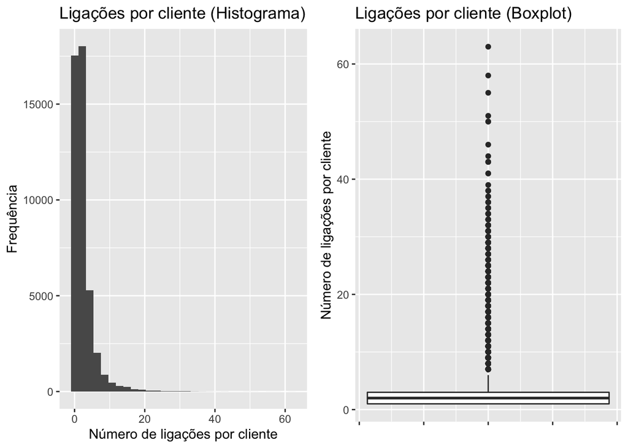

```r
hist <- ggplot(df, aes(x = campaign)) +
  geom_histogram(bins = 30) +
  ggtitle("Ligações por cliente (Histograma)") +
    labs(x = "Número de ligações por cliente",
         y = "Frequência")

boxplot <- ggplot(df, aes(y = campaign)) +
  geom_boxplot() +
  ggtitle("Ligações por cliente (Boxplot)") +
    labs(y = "Número de ligações por cliente",
         x = "") +
  theme(axis.text.x = element_blank())

grid.arrange(hist, boxplot, ncol = 2)
```

Como queremos saber a relação entre o número de ligações e o sucesso da campanha corremos o risco de tirar conclusões espúrias se tratarmos as poucas observações com números altos de ligações com o mesmo peso que as observações com muitas observações (poucas ligações).

Por isso, condensaremos as observações a partir de um limiar em que elas se tornam esparsas o suficiente para reduzir a segurança das inferências.

Exploramos os quantis dos dados para tentar encontrar um limiar razoável.

```r
df$campaign %>%
  quantile(probs = seq(0.05, 1, .05))
```

```
##   5%  10%  15%  20%  25%  30%  35%  40%  45%  50%  55%  60%  65%  70%  75%  80%
##    1    1    1    1    1    1    1    2    2    2    2    2    2    3    3    4
##  85%  90%  95% 100%
##    4    5    8   63
```

Podemos ver que os clientes com mais do que oito ligações representam menos de 5% dos dados. Assim, optamos por truncar todos aqueles clientes *com 9 ou mais* ligações em uma só categoria. Com isso a gente perde o nível intervalar da medida, e temos que atentar para isso nas análises que seguem.

```r
df <- df %>%
  # Criando uma nova variável com os dados acumulando-os na ponta extrema superior

  mutate(campaign_trunc = ifelse(campaign < 9, campaign, "9+"))
```

O uso do “9+” força a variável a se tornar do tipo `character`, que sinaliza a perda do nível intervalar da medida e impede descuidos de tirar médias com essa variável, por exemplo.

Agora vamos olhar para a nossa variável dependente, o sucesso da campanha, ou `y`.

```r
df$y %>%
  table() %>%
  prop.table()
```

```
## .
##        no       yes
## 0.8830152 0.1169848
```

A proporção de sucessos é muito menor que a de insucessos, isso é um ponto de atenção. Embora não seja uma assimetria tão crítica quanto a observada anteriormente. Vamos ter isso em mente para o futuro.

Vamos ver se essa distribuição se comporta entre os diferentes números de ligações realizadas

```r
df_prop_sucess <- df %>%
  group_by(campaign_trunc) %>%
  summarize(success_prop = mean(y == "yes"))

kable(df_prop_sucess, caption = "Tabela 2. Proporção de sucessos por quantidade de ligações para o cliente.")
```

Tabela 2. Proporção de sucessos por quantidade de ligações para o cliente.

| campaign_trunc | success_prop |
| --- | --- |
| 1 | 0.1459758 |
| 2 | 0.1120352 |
| 3 | 0.1119362 |
| 4 | 0.0900057 |
| 5 | 0.0787982 |
| 6 | 0.0712626 |
| 7 | 0.0639456 |
| 8 | 0.0592593 |
| 9+ | 0.0458357 |

Vemos que o número de ligações possui uma relação decrescente com a proporção de sucessos na campanha. Naturalmente que não podemos presumir uma relação de causalidade a partir desses dados, já que são apenas dados observacionais.

# Questão 3:

O número máximo de ligações pode ser estimado com base na probabilidade de sucesso de um número $X$ de ligações ou mais.

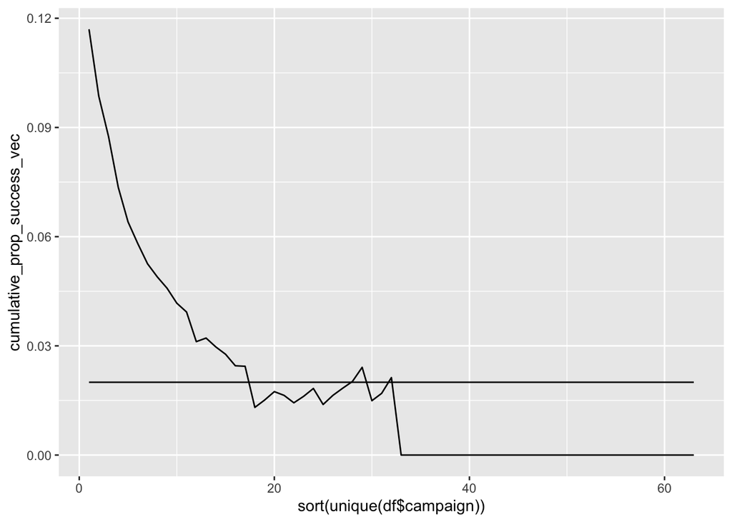

```r
cumulative_prop_success_vec <- numeric()
for(i in sort(unique(df$campaign))){
  cumulative_prop_success <- mean(df$y[df$campaign >= i] == "yes")
  cumulative_prop_success_vec <- c(cumulative_prop_success_vec,
                                   cumulative_prop_success)
}

ggplot(mapping = aes(x = sort(unique(df$campaign)),
           y = cumulative_prop_success_vec)) +
  geom_line() +
  geom_line(mapping = aes(y = .02))
```

A linha horizontal representa 2% de probabilidade de sucesso na ligação.

```r
index_max <- which(cumulative_prop_success_vec < 0.02) %>% min()

# Qual o número referente à primeira vez que a probabilidade de sucesso cruza o limiar?
sort(unique(df$campaign))[index_max]
```

```
## [1] 18
```

Ou seja, a partir da 18 ligação, a probabilidade de sucesso já é pequena o suficiente para ser desconsiderada. Esse pode ser o nosso número máximo.

A parte da pergunta sobre a média de ligações exige uma resposta não trivial. O objetivo é sempre maximizar a receita líquida com a adesão ao produto. Líquida aí no sentido de retirados os custos, inclusive, de aquisição de clientes. Para estimar o número médio e máximo de ligações, temos levar em conta tanto o *ticket médio do cliente*, quanto o *custo das ligações em horas trabalhadas* e a *probabilidade de sucesso de realizar mais uma ligação*. Vamos precisar aceitar alguns pressupostos para chegar a esses números.

#### Ticket Médio

O ticket médio seria um valor que poderíamos obter facilmente se estivéssemos em contato com o banco, mas vamos precisar estimá-lo. Como se trata de uma conta de depósito, o ticket médio está relacionado a quanto dinheiro o cliente provavelmente vai depositar nessa conta e no spread bancário médio em Portugal. Vamos assumir aqui que o spread bancário por lá é de $10\%$.

Temos o dado do saldo médio em conta do cliente (`balance`), vamos assumir que todo esse valor seria direcionado ao serviço contratado, permitindo que a gente estime o ticket médio do cliente usando a seguinte função:

```r
gen_average_ticket <- function(balance, bank_spread = 0.10){
  average_ticket <- balance*bank_spread
  return(average_ticket)
}
```

#### Custo de ligações em horas trabalhadas

Para estimar o custo médio das ligações vamos usar a variável `duration` e uma estimativa do salário de quem trabalha com customer service em portugal, em $€1000$ mensais. Daí deriva a função:

```r
gen_call_cost <- function(call_durations, salary = 1000){
  avg_duration <- mean(call_durations)
  call_cost <- (avg_duration/3600)*salary
  return(call_cost)
}
```

Agora vamos à probabilidade. A nossa probabilidade base foi calculada na questão anterior, mas podemos melhorar a qualidade dessa estimativa usando modelagem preditiva.

O primeiro passo é criar uma base de dados contendo apenas as variáveis que são conheciadas anteriormente à decisão de continuar ligando para o cliente.

Além disso, a variável `pdays` contém uma informação que não tem caráter numérico. O valor $-1$ indica que o cliente nunca fora contactado anteriormente a essa campanha. O que vamos fazer é dicotomizar a variável, seguindo o padrão de fator das outras variáveis categóricas. Vamos apenas manter a informação de se o cliente fora (“yes”) ou não (“no”) contactado antes dessa campanha.

```r
df <- read.table(unz("bank.zip", "bank-full.csv"),
                 header = TRUE, sep = ";", stringsAsFactors = TRUE)

df_model <- df %>%
  select(age, job, marital, education, default, balance, loan, pdays, previous, poutcome, y) %>%
  mutate(pdays = factor(ifelse(pdays > -1, "yes", "no")))
```

Essas alterações (seleção de variáveis e dicotomização da variável `pdays`) podem ser feitas direto na base inteira porque não são decisões tomadas com base na informação contida nos valores das variáveis, são decisões com base em conhecimentos prévios sobre a estrutura dos dados.

```r
set.seed(1)
partition_index <- sample(c(1, 2, 3), size = nrow(df_model),
                          prob = c(.7, .295, .005), replace = TRUE)
train_df <- df_model[partition_index == 1,]
test_df <- df_model[partition_index == 2,]
prod_df <- df_model[partition_index == 3,]
```

Usando apenas a base de treino como fonte de dados, algumas checagens nas variáveis se fazem importantes.

Primeiro buscamos se existem variáveis com pouca variabilidade.

```r
y_pos <- which(names(train_df) == "y")
nz_var <- nearZeroVar(train_df[,-y_pos], freqCut = 15)
names(train_df)[nz_var]
```

```
## [1] "default"
```

Vemos que a variável `default` é identificada por esse processo. Vamos investigar.

```r
train_df$default %>% table()
```

```
## .
##    no   yes
## 31066   589
```

```r
train_df$default %>% table() %>% prop.table()
```

```
## .
##         no        yes
## 0.98139314 0.01860686
```

Menos de 2% da base de treino possui registros de `default`. Essa configuração pode ser perigosa por superestimar a importância das poucas observações da base que possuem “yes” na variável `default`. O número baixo aumenta as chances de criar uma relação espúria entre esse preditor e a variável dependente. Observemos um cruzamento entre elas para ter mais informações.

```r
train_df$default %>% table(train_df$y) %>% prop.table(margin = 1)
```

```
##
## .            no       yes
##   no  0.8824438 0.1175562
##   yes 0.9286927 0.0713073
```

Como a distribuição de sucessos na campanha muda substancialmente entre os clientes que possuem ou não o dado positivo de `default`, ou seja, é mais difícil que o sinal seja expúrio. Vamos optar por não remover essa variável das bases.

Procuramos também dependências lineares entre as variáveis numéricas, o que costuma criar problemas para modelos paramétricos.

```r
factor_vars <- which(sapply(train_df, class) == "factor")
findLinearCombos(train_df[,-c(y_pos, factor_vars)])
```

```
## $linearCombos
## list()
##
## $remove
## NULL
```

Bom sinal!

Munidos dessas informações, procedemos à definição do objeto de preprocessamento dos dados.

```r
preproc_params <- preProcess(train_df, method = c("center", "scale"))
train_df_preproc <- predict(preproc_params, train_df)
test_df_preproc <- predict(preproc_params, test_df)
prod_df_preproc <- predict(preproc_params, prod_df)
```

Esse processo é de suma importância porque evita que utilizemos os dados de teste/produção para calibrar os parâmetros de normalização das variáveis numéricas.

A próxima etapa é avaliar a distribuição da nossa variável target.

```r
train_df_preproc$y %>% table()
```

```
## .
##    no   yes
## 27961  3694
```

```r
train_df_preproc$y %>% table() %>% prop.table()
```

```
## .
##        no       yes
## 0.8833044 0.1166956
```

Notamos de pronto que há um certo desbalanceamento de classes. Nada extremamente grave, mas que precisa ser adereçado de alguma forma.

Agora ao processo de ajuste e testagem dos modelos. Escolhemos modelos que lidam bem com tipos diferentes de variáveis preditoras que que possuem estratégias para produzir uma probabilidade como output. Um modelo paramétrico: regressão logística. E dois modelos não paramétricos, computacionais, a random forests e o Extreme Gradient Boosting, que tem resultados excelentes em diversas competições de desempenho preditivo. A escolha por modelos baseados em árvores deriva da natureza dos dados. A maioria dos preditores são de natureza categórica e modelos de árvores tendem a lidar bem com esse tipo de variável.

Para os modelos computacionais vamos usar o pacote caret, que cria um framework padronizado para comparar os modelos, além de simplificar o processo de tunning dos hiperparâmetros dos modelos.

```r
tr_control <- trainControl(method = "cv",
                           number = 5)

tr_control_down <- trainControl(method = "cv",
                           number = 5,
                           sampling = "down")
```

O número de variáveis sorteadas em cada uma das árvores da random forest (`mtry`) precisa ser selecionado. Aqui nós definimos os valores que serão comparados. Uma regra de bolso no caso das florestas randômicas é usar um inteiro próximo da raiz quadrada do número de variáveis preditoras. O valor $3$ cumpre esse papel.

```r
grid_rf <-  data.frame(mtry = c(1, 3, 5, 9))
```

Utilizamos a função wrapper `train()` que permite que recebe as configurações da nossa suite de treino e produz os parâmetros do modelo estimado, juntamente com algumas estatísticas de performance. Nela, configuramos também a métrica a ser usada na otimização, tal seja o Kappa de Cohen, que é mais adequado dado o desbalanceamento de classes, uma vez que a No Information Rate nesse caso é muito alta e a acurácia não é tão informativa.

```r
fit_rf <- train(y ~ ., data = train_df_preproc,
                 method = "rf",
                 trControl = tr_control,
                 verbose = FALSE,
                 tuneGrid = grid_rf,
                 metric = "Kappa")

fit_rf_down <- train(y ~ ., data = train_df_preproc,
                 method = "rf",
                 trControl = tr_control_down,
                 verbose = FALSE,
                 tuneGrid = grid_rf,
                 metric = "Kappa")
```

Seguimos a mesma estrutura para o modelo de Extreme Gradient Boosting. A diferença é que esse modelo exige uma atenção maior para a tunagem dos parâmetros. Como são muitos parâmetros diferentes, a quantidade de combinações pode sair de controle rapidamente. Essa parte da modelagem merece bastante atenção.

Vamos utilizar uma estratégia *gulosa* para otimizar os hiperparâmetros. A primeira etapa é criar um grid de tunning com os valores padrão do xgbTree para servir de baseline.

```r
tr_control <- trainControl(method = "cv",
                           number = 5)

#Valores padrão dos hiperparâmetros
grid_xgbTree <-  expand.grid(nrounds = 100,
                        max_depth = 6,
                        eta = .3,
                        gamma = 0,
                        colsample_bytree = c(.3),
                        min_child_weight = 1,
                        subsample = 1)


fit_xgbTree_baseline <- train(y ~ ., data = train_df_preproc,
                     method = "xgbTree",
                     trControl = tr_control,
                     tuneGrid = grid_xgbTree,
                     metric = "Kappa",
                     verbose = FALSE)

fit_xgbTree_baseline$results
```

```
##   nrounds max_depth eta gamma colsample_bytree min_child_weight subsample
## 1     100         6 0.3     0              0.3                1         1
##    Accuracy     Kappa  AccuracySD    KappaSD
## 1 0.8907281 0.2291495 0.002499374 0.01750613
```

Temos o nosso baseline!

Vamos começar tentando variar a taxa de aprendizagem menor, mas para isso precisamos dar também ao algoritmo mais iterações, já que aprenderá mais lentamente.

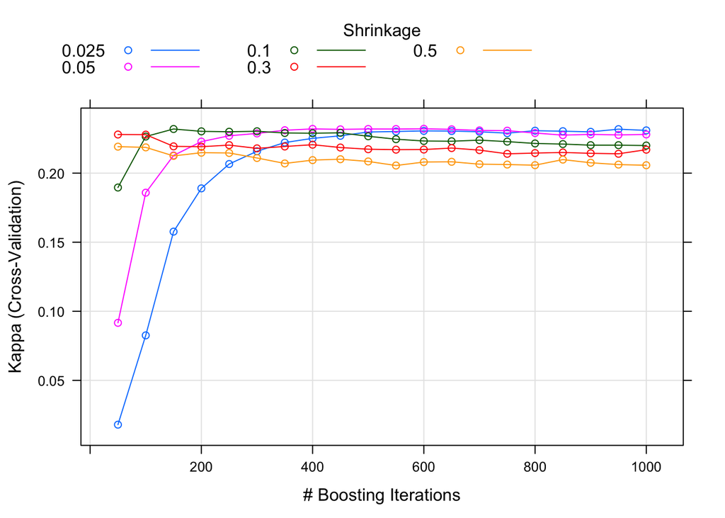

```r
tr_control <- trainControl(method = "cv",
                           number = 5,
                           allowParallel = TRUE) # Permite que cada combinação de parâmetros seja feita em paralelo

grid_xgbTree_1 <-  expand.grid(nrounds = seq(from = 50, to = 1000, by = 50),
                        max_depth = 6,
                        eta = c(0.025, 0.05, .1, .3, .5),
                        gamma = 0,
                        colsample_bytree = c(.3),
                        min_child_weight = 1,
                        subsample = 1)


fit_xgbTree_1 <- train(y ~ ., data = train_df_preproc,
                     method = "xgbTree",
                     trControl = tr_control,
                     tuneGrid = grid_xgbTree_1,
                     metric = "Kappa",
                     verbose = FALSE)

plot(fit_xgbTree_1)
```

Vemos que o número de iterações cumpre o papel esperado para as taxas de aprendizado mais lentas. Com estabilização em torno de $500$ iterações. O desempenho das diferentes taxas de aprendizado não possui muita variabilidade entre eles. Vamos optar por uma taxa de aprendizagem intermediária, de $0.05$, e vamos deixar as iterações subirem até $600$.

Agora vamos variar o número máximo de níveis das árvores (`max_depth`) bem como o número de colunas amostradas para a construção de cada árvore.

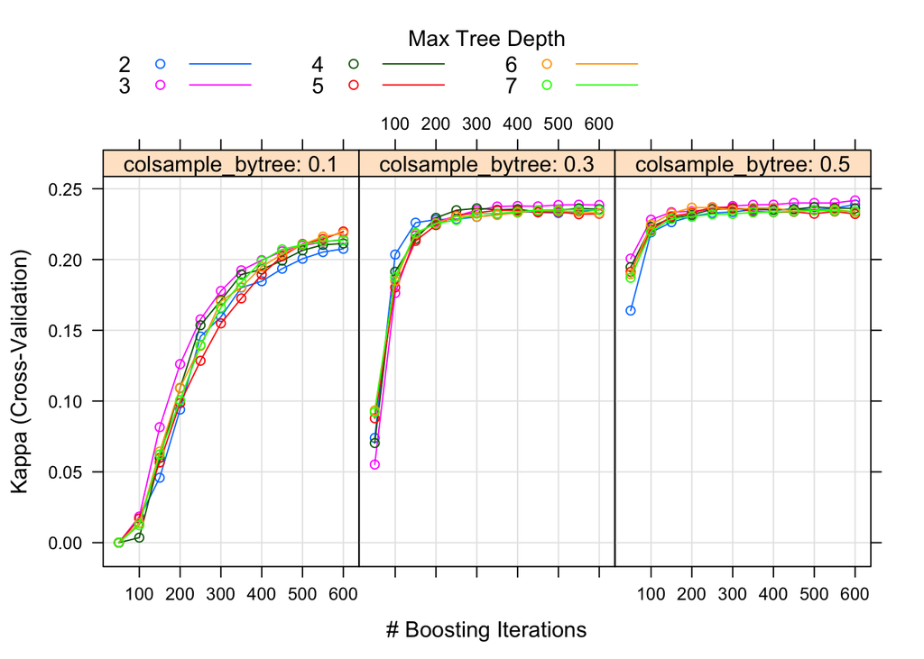

```r
tr_control <- trainControl(method = "cv",
                           number = 5,
                           allowParallel = TRUE) # Permite que cada combinação de parâmetros seja feita em paralelo

grid_xgbTree_2 <-  expand.grid(nrounds = seq(from = 50, to = 600, by = 50),
                        max_depth = 2:7,
                        eta = c(0.05),
                        gamma = 0,
                        colsample_bytree = c(.1, .3, .5),
                        min_child_weight = 1,
                        subsample = 1)


fit_xgbTree_2 <- train(y ~ ., data = train_df_preproc,
                     method = "xgbTree",
                     trControl = tr_control,
                     tuneGrid = grid_xgbTree_2,
                     metric = "Kappa",
                     verbose = FALSE)

plot(fit_xgbTree_2)
```

```r
fit_xgbTree_2$bestTune
```

```
##    nrounds max_depth  eta gamma colsample_bytree min_child_weight subsample
## 72     600         3 0.05     0              0.5                1         1
```

Conforme o desempenho das amostras de validação cruzada, selecionamos a proporção de .5 na amostra das colunas, e o número máximo de divisões da árvore em 3.

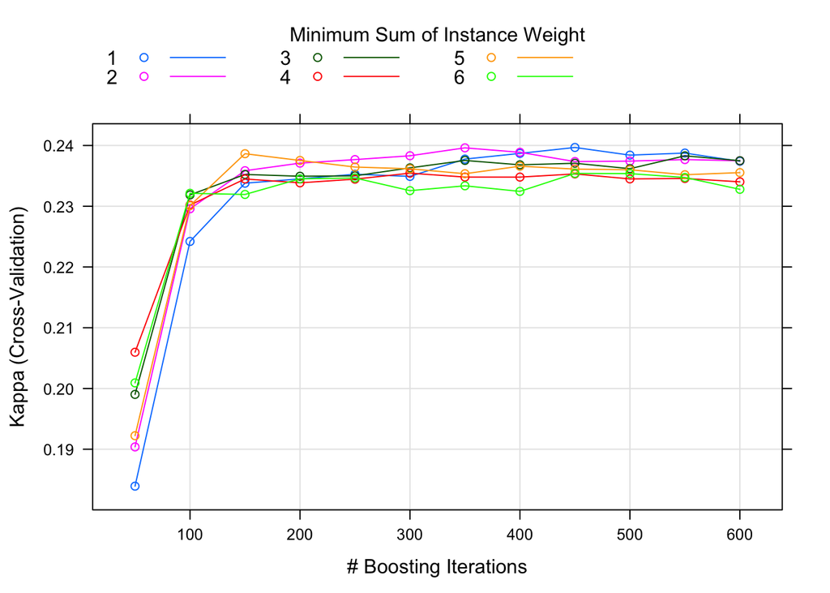

```r
tr_control <- trainControl(method = "cv",
                           number = 5,
                           allowParallel = TRUE) # Permite que cada combinação de parâmetros seja feita em paralelo

grid_xgbTree_final <-  expand.grid(nrounds = seq(from = 50, to = 600, by = 50),
                                   max_depth = 3,
                                   eta = c(0.05),
                                   gamma = 0,
                                   colsample_bytree = c(.5),
                                   min_child_weight = 1:6,
                                   subsample = 1)


fit_xgbTree_final <- train(y ~ ., data = train_df_preproc,
                           method = "xgbTree",
                           trControl = tr_control,
                           tuneGrid = grid_xgbTree_final,
                           metric = "Kappa",
                           verbose = FALSE)

plot(fit_xgbTree_final)
```

Novamente, pouca diferenciação, e esse é o nosso modelo final.

```r
fit_xgbTree_final$bestTune
```

```
##   nrounds max_depth  eta gamma colsample_bytree min_child_weight subsample
## 9     450         3 0.05     0              0.5                1         1
```

Esse processo poderia continuar mais a fundo, mas temos que tomar cuidado também para não testar combinações de parâmetros o suficiente para aumentar substancialmente a probabilidade de encontrar uma combinação com bons resultados ao acaso.

Procedamos ao encaixe do último modelo: a regressão logística.

```r
fit_logistic <- glm(y~., data = train_df_preproc,
    family = binomial(link = "logit"))
fit_logistic_step <- step(fit_logistic, direction = "backward")
```

```
## Start:  AIC=20437.22
## y ~ age + job + marital + education + default + balance + loan +
##     pdays + previous + poutcome
##
##             Df Deviance   AIC
## - previous   1    20386 20436
## - default    1    20386 20436
## - pdays      1    20387 20437
## <none>            20385 20437
## - age        1    20393 20443
## - balance    1    20403 20453
## - education  3    20417 20463
## - marital    2    20448 20496
## - loan       1    20450 20500
## - job       11    20609 20639
## - poutcome   3    21318 21364
##
## Step:  AIC=20435.75
## y ~ age + job + marital + education + default + balance + loan +
##     pdays + poutcome
##
##             Df Deviance   AIC
## - default    1    20386 20434
## - pdays      1    20387 20435
## <none>            20386 20436
## - age        1    20393 20441
## - balance    1    20403 20451
## - education  3    20418 20462
## - marital    2    20448 20494
## - loan       1    20450 20498
## - job       11    20610 20638
## - poutcome   3    21318 21362
##
## Step:  AIC=20434.53
## y ~ age + job + marital + education + balance + loan + pdays +
##     poutcome
##
##             Df Deviance   AIC
## - pdays      1    20388 20434
## <none>            20386 20434
## - age        1    20394 20440
## - balance    1    20404 20450
## - education  3    20418 20460
## - marital    2    20449 20493
## - loan       1    20452 20498
## - job       11    20611 20637
## - poutcome   3    21319 21361
##
## Step:  AIC=20434.22
## y ~ age + job + marital + education + balance + loan + poutcome
##
##             Df Deviance   AIC
## <none>            20388 20434
## - age        1    20396 20440
## - balance    1    20406 20450
## - education  3    20420 20460
## - marital    2    20450 20492
## - loan       1    20454 20498
## - job       11    20614 20638
## - poutcome   3    21959 21999
```

O último passo para a comparação dos modelos consiste em encontrar o limiar que maximiza a soma dos quadrados da especificidade e da sensitividade. Para isso, vamos usar a curva ROC.

```r
find_best_thresh <- function(roc_obj){
  index_max <- which.max((roc_obj$sensitivities)^2 + (roc_obj$specificities)^2)
  return(roc_obj$thresh[index_max])
}

train_preds_rf <- predict(fit_rf, newdata = train_df_preproc, type = "prob")
train_preds_rf_down <- predict(fit_rf_down, newdata = train_df_preproc, type = "prob")
train_preds_xgboost <- predict(fit_xgbTree_final, newdata = train_df_preproc, type = "prob")
train_preds_logistic <- predict(fit_logistic, newdata = train_df_preproc, type = "response")
train_preds_logistic_step <- predict(fit_logistic_step, newdata = train_df_preproc, type = "response")

roc_rf <- roc(train_df_preproc$y, train_preds_rf$yes)
thresh_rf <- find_best_thresh(roc_rf)
roc_rf_down <- roc(train_df_preproc$y, train_preds_rf_down$yes)
thresh_rf_down <- find_best_thresh(roc_rf_down)
roc_xgboost <- roc(train_df_preproc$y, train_preds_xgboost$yes)
thresh_xgboost <- find_best_thresh(roc_xgboost)
roc_logistic <- roc(train_df_preproc$y, train_preds_logistic)
thresh_logistic <- find_best_thresh(roc_logistic)
roc_logistic_step <- roc(train_df_preproc$y, train_preds_logistic_step)
thresh_logistic_step <- find_best_thresh(roc_logistic_step)
```

E agora à análise de desempenho com a base de testes:

```r
predict_rf <- predict(fit_rf, newdata = test_df_preproc, type = "prob") %>%
  pull(yes) %>%
  {ifelse(.>thresh_rf, "yes", "no")} %>%
  factor()
predict_rf_down <- predict(fit_rf_down, newdata = test_df_preproc, type = "prob") %>%
  pull(yes) %>%
  {ifelse(.>thresh_rf_down, "yes", "no")} %>%
  factor()
predict_xgboost <- predict(fit_xgbTree_final, newdata = test_df_preproc, type = "prob") %>%
  pull(yes) %>%
  {ifelse(.>thresh_xgboost, "yes", "no")} %>%
  factor()

predict_logistic <- predict(fit_logistic, newdata = test_df_preproc, type = "response") %>%
  {ifelse(.>thresh_logistic, "yes", "no")} %>%
  factor()

predict_logistic_step <- predict(fit_logistic_step, newdata = test_df_preproc) %>%
  {ifelse(.>thresh_logistic_step, "yes", "no")} %>%
  factor()

confusion_rf <- confusionMatrix(test_df_preproc$y, predict_rf, positive = "yes")
confusion_rf_down <- confusionMatrix(test_df_preproc$y, predict_rf_down, positive = "yes")
confusion_xgboost <- confusionMatrix(test_df_preproc$y, predict_xgboost, positive = "yes")
confusion_logistic <- confusionMatrix(test_df_preproc$y, predict_logistic, positive = "yes")
confusion_logistic_step <- confusionMatrix(test_df_preproc$y, predict_logistic_step, positive = "yes")

extract_cm_info <- function(cm_data){
  out <- c(cm_data$overall[c("Accuracy", "Kappa")],
      cm_data$byClass[c("Sensitivity", "Specificity", "Pos Pred Value", "Neg Pred Value", "F1")])
  return(out)
}

performance_comparison <- data.frame(model = c("RF", "RF - Downsample", "XGBoost", "Logistic", "Logistic Step"),
                                     rbind(extract_cm_info(confusion_rf),
                                           extract_cm_info(confusion_rf_down),
                                           extract_cm_info(confusion_xgboost),
                                           extract_cm_info(confusion_logistic),
                                           extract_cm_info(confusion_logistic_step)),
                                     stringsAsFactors = FALSE)
```

```r
kable(performance_comparison, caption = "Tabela 3. Comparação de desempenho entre diferentes modelos preditivos")
```

Tabela 3. Comparação de desempenho entre diferentes modelos preditivos

| model | Accuracy | Kappa | Sensitivity | Specificity | Pos.Pred.Value | Neg.Pred.Value | F1 |
| --- | --- | --- | --- | --- | --- | --- | --- |
| RF | 0.6700458 | 0.1322122 | 0.1903825 | 0.9210707 | 0.5579757 | 0.6849268 | 0.2838983 |
| RF - Downsample | 0.8630322 | 0.2727276 | 0.3936944 | 0.9110927 | 0.3119795 | 0.9362028 | 0.3481058 |
| XGBoost | 0.8815799 | 0.2943109 | 0.4909091 | 0.9092225 | 0.2767457 | 0.9618918 | 0.3539533 |
| Logistic | 0.8931441 | 0.2483841 | 0.6589862 | 0.9010324 | 0.1832159 | 0.9874107 | 0.2867168 |
| Logistic Step | 0.8908913 | 0.1857866 | 0.6849315 | 0.8955086 | 0.1281230 | 0.9921742 | 0.2158662 |

```r
calc_prob_success <- function(fit_model, x_vec, fit_thresh){
  prob_success <- predict(fit_model, newdata = x_vec, type = "response")
}
```

```r
calc_n_calls <- function(balance, call_durations, fit_model, x_vec){
  average_ticket <- gen_average_ticket(balance)
  call_cost <- gen_call_cost(call_durations)
  prob_success <- calc_prob_success(fit_model, x_vec)
  n_calls <- (average_ticket*prob_success)/call_cost
  out <- min(ceiling(n_calls), 18) # O nosso número máximo do começo da questão
  return(ceiling(n_calls))
}

calc_n_calls(balance = prod_df$balance[127],
             call_durations = df$duration,
             fit_model = fit_logistic,
             x_vec = prod_df_preproc[127,])
```

```
## 27284
##     3
```

No caso desse cliente em específico, dados os pressupostos acima, faria sentido ligar até 3 vezes para ele.

# Questão 4

```r
df$poutcome %>% table()
```

```
## .
## failure   other success unknown
##    4901    1840    1511   36959
```

```r
df$poutcome %>% table(df$y) %>% prop.table(margin = 1)
```

```
##
## .                 no        yes
##   failure 0.87390329 0.12609671
##   other   0.83315217 0.16684783
##   success 0.35274653 0.64725347
##   unknown 0.90838497 0.09161503
```

```r
df$poutcome %>% table(df$y) %>% chisq.test()
```

```
##
##  Pearson's Chi-squared test
##
## data:  .
## X-squared = 4391.5, df = 3, p-value < 2.2e-16
```

A pergunta se uma variável tem relação com outra pode ser respondida com o teste de associação. Conhecido como teste de Qui-quadrado. Como vemos acima o resultado é significativo, as variáveis estão associadas. Particularmente, o sucesso em campanhas anteriores parece aumentar drasticamente a probabilidade de sucesso na campanha atual.

# Questão 5

Não encontrei nos dados referência alguma sobre a questão de um seguro de crédito, mas imagino que a variável determinante seria a clientes com a presença de histórico de default.

# Questão 6

```r
df <- read.table(unz("bank.zip", "bank-full.csv"),
                 header = TRUE, sep = ";", stringsAsFactors = TRUE)

df %>%
  group_by(housing) %>%
  summarize(
    mean_age = mean(age),
    median_age = median(age),
    job = names(sort(table(job), decreasing = TRUE)[1]),
    marital_status = names(sort(table(marital), decreasing = TRUE)[1]),
    education = names(sort(table(education), decreasing = TRUE)[1]),
    default = names(sort(table(default), decreasing = TRUE)[1]),
    mean_balance = mean(balance),
    loan = names(sort(table(loan), decreasing = TRUE)[1]),
    contact = names(sort(table(contact), decreasing = TRUE)[1]),
    day = names(sort(table(day), decreasing = TRUE)[1]),
    month = names(sort(table(month), decreasing = TRUE)[1]),
    duration = mean(duration),
    campaign = mean(campaign),
    pdays = mean(pdays),
    previous_mean = mean(previous),
    previous_median = median(previous),
    poutcome = names(sort(table(poutcome), decreasing = TRUE)[2]),
    y = names(sort(table(y), decreasing = TRUE)[1])) %>% t() %>%
  kable(caption = "Tabela 4. Principais características de quem possui empréstimo imobiliário")
```

Tabela 4. Principais características de quem possui empréstimo imobiliário

| housing | no | yes |
| --- | --- | --- |
| mean_age | 43.13988 | 39.17529 |
| median_age | 42 | 38 |
| job | management | blue-collar |
| marital_status | married | married |
| education | secondary | secondary |
| default | no | no |
| mean_balance | 1596.501 | 1175.103 |
| loan | no | no |
| contact | cellular | cellular |
| day | 20 | 20 |
| month | aug | may |
| duration | 256.7009 | 259.3315 |
| campaign | 2.845625 | 2.698488 |
| pdays | 26.28858 | 51.31250 |
| previous_mean | 0.4847866 | 0.6566653 |
| previous_median | 0 | 0 |
| poutcome | failure | failure |
| y | no | no |

O grupo daqueles que têm empréstimo imobiliário é bem parecido com o grupo que não tem. Algumas diferenças pontuais no mês mais frequente de comunicação, no número de contatos por telefone até a última campanha e uma diferença substancial na média de dinheiro em caixa.